# Module 5: Nonparametric Statistical Methods and Sampling

Sankalp Susil Kumar Biswal, ALY6015 Intermediate Analytics

2024-02-11

# Introduction:

This project encapsulates the essence of nonparametric statistical methods through the simulation of real-world scenarios, allowing us to delve into the practical applications of these techniques. By harnessing the power of R, a versatile statistical programming language, we simulate various situations - from game attendance and lottery ticket sales to the analysis of prison sentence lengths and baseball game outcomes. Through each simulation, we test hypotheses and draw conclusions that aid in decision-making processes, which are pivotal in fields as diverse as sports management, retail, public administration, and beyond.

# Section 13-2.6 Game Attendance

An athletic director suggests the median number for the paid attendance at 20 local football games is 3000. The data for a random sample are shown. At α = 0.05, is there enough evidence to reject the claim? If you were printing the programs for the games, would you use this figure as a guide?

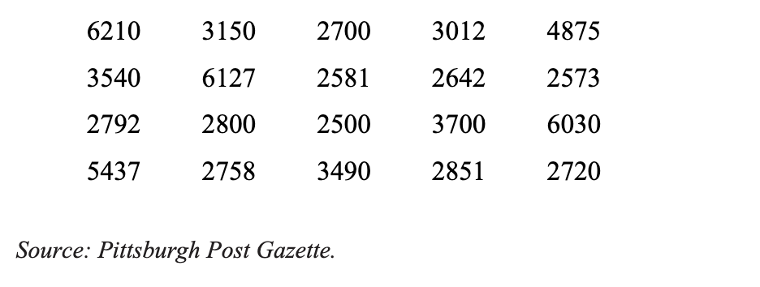

# Solution

## *Sign Test*

## Forming the dataset

```r
attendance <- c(
  6210, 3150, 2700, 3012, 4875,
  3540, 6127, 2581, 2642, 2573,
  2792, 2800, 2500, 3700, 6030,
  5437, 2758, 3490, 2851, 2720
)
```

### Step 1. Stating the hypotheses and identifying the claim

The hypothesis for the above will be as follow:

```r
# Print the Null and Alternative Hypothesis
cat("Null Hypothesis (H0): The median number of the paid attendance at the local football games is 3000.\n\n")
```

```
## Null Hypothesis (H0): The median number of the paid attendance at the local football games is 3000.
```

```r
cat("Alternative Hypothesis (H1): The median number of the paid attendance at the local football games is not 3000.\n")
```

```
## Alternative Hypothesis (H1): The median number of the paid attendance at the local football games is not 3000.
```

### Step 2. Finding the critical value

When using the p-value for analysis, no critical value is needed. Because of this, we will use the provided p-value and omit this step.

We will use alpha = 0.05.

```r
alpha <- 0.05
```

### Step 3. Computing the test results

```r
# Define the hypothesized median value
hypothesized_median <- 3000

# Perform the Sign Test
# Count the number of games with attendance above the hypothesized median
above_median <- sum(attendance > hypothesized_median)
# Count the number of games with attendance below the hypothesized median
below_median <- sum(attendance < hypothesized_median)
# The Sign Test is effectively a binomial test with p = 0.5
binom_test <- binom.test(x = above_median, n = above_median + below_median, p = 0.5, alternative = "two.sided")

# Output the results of the test
binom_test
```

```
##
##  Exact binomial test
##
## data:  above_median and above_median + below_median
## number of successes = 10, number of trials = 20, p-value = 1
## alternative hypothesis: true probability of success is not equal to 0.5
## 95 percent confidence interval:
##  0.2719578 0.7280422
## sample estimates:
## probability of success
##                    0.5
```

### Step 4. Make the decision

**P-value:** The p-value is 1, which is much higher than the common alpha level of 0.05. This indicates that there is no statistical evidence to reject the null hypothesis.

### Step 5. Summary

In summary, the test results do not provide enough evidence to conclude that the true median attendance is different from 3000.

**We do not reject the null hypothesis.**

# Section 13-2.10 Lottery Ticket Sales

A lottery outlet owner hypothesizes that she sells 200 lottery tickets a day. She randomly sampled 40 days and found that on 15 days she sold fewer than 200 tickets. At α = 0.05, is there sufficient evidence to conclude that the median is below 200 tickets?

# Solution

## *Sign Test*

### Step 1. Stating the hypotheses and identifying the claim

The hypothesis for the above will be as follow:

```r
# Print the Null and Alternative Hypothesis
cat("Null Hypothesis (H0): The median number of lottery tickets sold per day is 200.\n\n")
```

```
## Null Hypothesis (H0): The median number of lottery tickets sold per day is 200.
```

```r
cat("Alternative Hypothesis (H1): The median number of lottery tickets sold per day is less than 200.\n")
```

```
## Alternative Hypothesis (H1): The median number of lottery tickets sold per day is less than 200.
```

### Step 2. Finding the critical value

When using the p-value for analysis, no critical value is needed. Because of this, we will use the provided p-value and omit this step.

We will use alpha = 0.05.

```r
alpha <- 0.05
```

### Step 3. Computing the test results

```r
# Number of days sampled
n <- 40

# Number of days with fewer than 200 tickets sold
x <- 15

# Probability under the null hypothesis
p <- 0.5

# Significance level
alpha <- 0.05

# Perform the binomial test
binom_test <- binom.test(x, n, p, alternative = "less")

# Output the results of the test
binom_test
```

```
##
##  Exact binomial test
##
## data:  x and n
## number of successes = 15, number of trials = 40, p-value = 0.07693
## alternative hypothesis: true probability of success is less than 0.5
## 95 percent confidence interval:
##  0.0000000 0.5172483
## sample estimates:
## probability of success
##                  0.375
```

### Step 4. Analyzing the results

**P-value:** The p-value is approximately 0.07693. Since this value is greater than the significance level of 0.05, there is not enough statistical evidence to reject the null.

### Step 5. Summary

The owner thus does not have sufficient grounds to reject her initial hypothesis that she sells 200 tickets a day based on this sample.

**We do not reject the null hypothesis.**

# Section 13-3.4 Lengths of Prison Sentences

A random sample of men and women in prison was asked to give the length of sentence each received

for a certain type of crime. At α = 0.05, test the claim that there is no difference in the sentence

received by each gender. The data (in months) are shown here

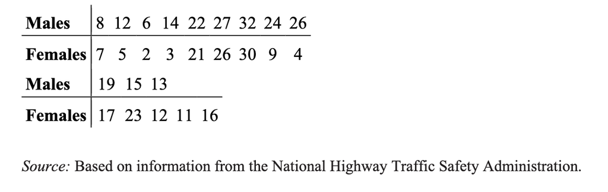

# Solution

## *Wilcoxon rank sum test*

## Forming the dataset

```r
# Input the data
males <- c(8, 12, 6, 14, 22, 27, 32, 24, 26, 19, 15, 13)
females <- c(7, 5, 2, 3, 21, 26, 30, 9, 4, 17, 23, 12, 11, 16)
```

### Step 1. Stating the hypotheses and identifying the claim

The hypothesis for the above will be as follow:

```r
# Print the Null and Alternative Hypothesis for the Wilcoxon rank-sum test
cat("Null Hypothesis (H0): There is no difference in the distributions of sentence lengths between males and females.\n\n")
```

```
## Null Hypothesis (H0): There is no difference in the distributions of sentence lengths between males and females.
```

```r
cat("Alternative Hypothesis (H1): There is a difference in the distributions of sentence lengths between males and females.\n")
```

```
## Alternative Hypothesis (H1): There is a difference in the distributions of sentence lengths between males and females.
```

### Step 2. Finding the critical value

When using the p-value for analysis, no critical value is needed. Because of this, we will use the provided p-value and omit this step.

We will use alpha = 0.05.

```r
alpha <- 0.05
```

### Step 3. Computing the test results

```r
# Perform the Wilcoxon rank-sum test
test_result <- wilcox.test(males, females, alternative = "two.sided")
# Output the results of the test
test_result
```

```
##
##  Wilcoxon rank sum test with continuity correction
##
## data:  males and females
## W = 113, p-value = 0.1425
## alternative hypothesis: true location shift is not equal to 0
```

### Step 4. Analyzing the results

**P-value = 0.1425:** The p-value is above the conventional significance level of 0.05, which means that the test did not find enough evidence to reject the null hypothesis at the 5% significance level.

### Step 5. Summary

**We do not reject the null hypothesis.**

# Section 13-3.8 Winning Baseball Games

For the years 1970–1993 the National League (NL) and the American League (AL) (major league

baseball) were each divided into two divisions: East and West. Below are random samples of the

number of games won by each league’s Eastern Division. At α = 0.05, is there sufficient evidence to

conclude a difference in the number of wins?

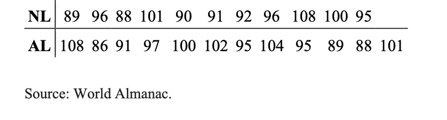

# Solution

## *Wilcoxon rank sum test*

## Forming the dataset

```r
# Input the data
NL_wins <- c(89, 96, 88, 101, 90, 91, 92, 96, 108, 100, 95)
AL_wins <- c(108, 86, 91, 97, 100, 102, 95, 104, 95, 89, 88, 101)
```

### Step 1. Stating the hypotheses and identifying the claim

The hypothesis for the above will be as follow:

```r
# Print the Null and Alternative Hypothesis
cat("Null Hypothesis (H0): There is no difference in the mean number of games won by each league's Eastern Division.\n\n")
```

```
## Null Hypothesis (H0): There is no difference in the mean number of games won by each league's Eastern Division.
```

```r
cat("Alternative Hypothesis (H1): There is a difference in the mean number of games won by each league's Eastern Division.\n")
```

```
## Alternative Hypothesis (H1): There is a difference in the mean number of games won by each league's Eastern Division.
```

### Step 2. Finding the critical value

When using the p-value for analysis, no critical value is needed. Because of this, we will use the provided p-value and omit this step.

We will use alpha = 0.05.

```r
alpha <- 0.05
```

### Step 3. Computing the test results

```r
# Perform the Wilcoxon rank-sum test
wilcox_test_result <- wilcox.test(NL_wins, AL_wins, paired = FALSE)
# Output the results of the Wilcoxon test
wilcox_test_result
```

```
##
##  Wilcoxon rank sum test with continuity correction
##
## data:  NL_wins and AL_wins
## W = 59, p-value = 0.6883
## alternative hypothesis: true location shift is not equal to 0
```

### Step 4. Analyzing the results

**P-value =** A p-value of 0.6883 is quite high, much greater than the common alpha level of 0.05, indicating that the observed difference in wins between the two leagues is not statistically significant.

### Step 5. Summary

Thus, based on this sample data, we cannot say that there is a statistically significant difference in the median number of games won by the NL’s Eastern Division compared to the AL’s Eastern Division.

**We do not reject the null hypothesis.**

# Section 13-4.A

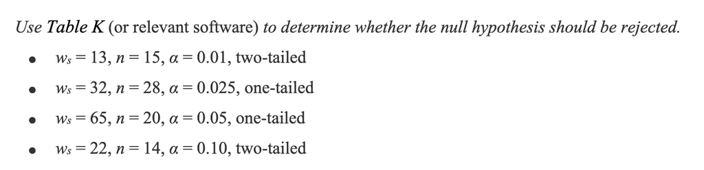

# Solution

## *Wilcoxon signed rank test*

## Forming the dataset

```r
# Scenarios provided
scenarios <- list(
  list(w = 13, n = 15, alpha = 0.01, tail = "two.sided"),
  list(w = 32, n = 28, alpha = 0.025, tail = "less"),
  list(w = 65, n = 20, alpha = 0.05, tail = "less"),
  list(w = 22, n = 14, alpha = 0.10, tail = "two.sided")
)
```

### Step 1. Stating the hypotheses and identifying the claim

The hypothesis for the above will be as follow:

1. For a two-tailed test (testing if there is any difference):
   - **Null Hypothesis (H0):** The median of the two independent samples is equal.
   - **Alternative Hypothesis (H1):** The median of the two independent samples is not equal.
2. For a one-tailed test (testing if one median is greater or less than the other):
   - **Null Hypothesis (H0):** The median of the first sample is less than or equal to the median of the second sample (if testing for “greater”) or the median of the first sample is greater than or equal to the median of the second sample (if testing for “less”).
   - **Alternative Hypothesis (H1):** The median of the first sample is greater than the median of the second sample (if testing for “greater”) or the median of the first sample is less than the median of the second sample (if testing for “less”).

### Step 2. Finding the critical value

When using the p-value for analysis, no critical value is needed. Because of this, we will use the provided p-value and omit this step.

```r
alpha <- 0.05
```

### Step 3. Computing the test results

```r
# Function to perform Wilcoxon Rank Sum Test (OpenAI,2024)
perform_test <- function(w, n, alpha, tail, test_number) {
  z <- (w - n*(n+1)/4) / sqrt(n*(n+1)*(2*n+1)/24)
  p_value <- switch(tail,
                    "less" = pnorm(z),
                    "greater" = pnorm(z, lower.tail = FALSE),
                    "two.sided" = 2 * pnorm(abs(z), lower.tail = FALSE))
  list(test_number = test_number, statistic = z, p_value = p_value, reject_null = (p_value < alpha))
}

# Applying the test to each scenario
results <- lapply(1:length(scenarios), function(i) perform_test(scenarios[[i]]$w, scenarios[[i]]$n, scenarios[[i]]$alpha, scenarios[[i]]$tail, test_number = i))

# Print results
for (i in 1:length(results)) {
  cat("Test Number", i, "\n")
  print(results[[i]])
}
```

```
## Test Number 1
## $test_number
## [1] 1
##
## $statistic
## [1] -2.669421
##
## $p_value
## [1] 0.007598223
##
## $reject_null
## [1] TRUE
##
## Test Number 2
## $test_number
## [1] 2
##
## $statistic
## [1] -3.893913
##
## $p_value
## [1] 4.931994e-05
##
## $reject_null
## [1] TRUE
##
## Test Number 3
## $test_number
## [1] 3
##
## $statistic
## [1] -1.493307
##
## $p_value
## [1] 0.06767845
##
## $reject_null
## [1] FALSE
##
## Test Number 4
## $test_number
## [1] 4
##
## $statistic
## [1] -1.914683
##
## $p_value
## [1] 0.05553298
##
## $reject_null
## [1] TRUE
```

### Step 4. Analyzing the results

1. **First Test:**
   - **P-value:** 0.007598223, which is less than the alpha level of 0.01. This is a small p-value indicating that the result is statistically significant.
   - **Reject Null:** TRUE, which means that we would reject the null hypothesis for this test, concluding that there is a significant difference.
2. **Second Test:**
   - **P-value:** 4.931994e-05, which is significantly less than the alpha level of 0.025. This very small p-value indicates strong evidence against the null hypothesis.
   - **Reject Null:** TRUE, meaning that we would reject the null hypothesis, concluding a significant difference.
3. **Third Test:**
   - **P-value:** 0.06767845, which is greater than the alpha level of 0.05. This suggests that the result is not statistically significant.
   - **Reject Null:** FALSE, meaning that we would not reject the null hypothesis for this test. There is not enough evidence to conclude a significant difference.
4. **Fourth Test:**
   - **P-value:** 0.05553298, which is close to the alpha level of 0.10.
   - **Reject Null:** TRUE, meaning that we would reject the null hypothesis.

# Section 13-5.2 Mathematics Literacy Scores

Through the Organization for Economic Cooperation and Development (OECD), 15-year-olds are tested

in member countries in mathematics, reading, and science literacy. Listed are randomly selected total

mathematics literacy scores (i.e., both genders) for selected countries in different parts of the world.

Test, using the Kruskal-Wallis test, to see if there is a difference in means at α = 0.05.

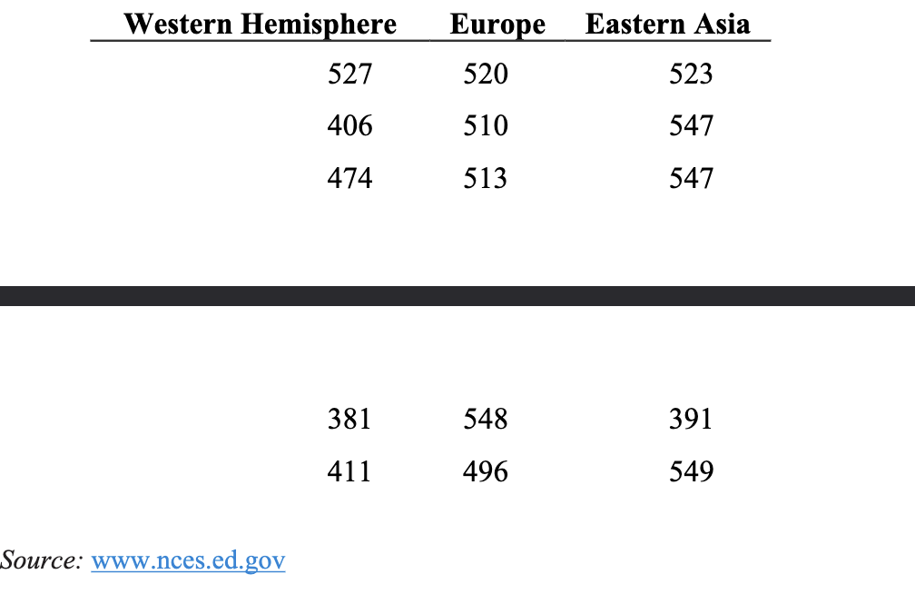

# Solution

## *Kruskal wallis Test*

## Forming the dataset

```r
western_hemisphere <- c(527, 406, 474, 381, 411)
europe <- c(520, 510, 513, 548, 496)
eastern_asia <- c(523, 547, 547, 391, 549)

# Combine the data into a list and create a factor indicating the group of each observation
scores <- c(western_hemisphere, europe, eastern_asia)
groups <- factor(rep(c("Western Hemisphere", "Europe", "Eastern Asia"),
                     each = length(western_hemisphere)))
```

### Step 1. Stating the hypotheses and identifying the claim

The hypothesis for the above will be as follow:

```r
# Print the Null and Alternative Hypothesis
cat("Null Hypothesis (H0): The median mathematics literacy scores are the same across the different regions.\n\n")
```

```
## Null Hypothesis (H0): The median mathematics literacy scores are the same across the different regions.
```

```r
cat("Alternative Hypothesis (H1): At least one region has a different median mathematics literacy score from the others.\n")
```

```
## Alternative Hypothesis (H1): At least one region has a different median mathematics literacy score from the others.
```

### Step 2. Finding the critical value

When using the p-value for analysis, no critical value is needed. Because of this, we will use the provided p-value and omit this step.

We will use alpha = 0.05.

```r
alpha <- 0.05
```

### Step 3. Computing the test results

```r
# Perform the Kruskal-Wallis test
kruskal_test <- kruskal.test(scores, groups)

# Output the results of the test
kruskal_test
```

```
##
##  Kruskal-Wallis rank sum test
##
## data:  scores and groups
## Kruskal-Wallis chi-squared = 4.1674, df = 2, p-value = 0.1245
```

### Step 4. Make the decision

**P-value =** Given the p-value is 0.1245, which is greater than the alpha level of 0.05, we do not reject the null hypothesis.

### Step 5. Summary

In summary, based on this sample, it appears that the mathematics literacy scores are not significantly different across the regions tested at the 5% significance level.

**We do not reject the null hypothesis.**

# Section 13-6.6 Subway and Commuter Rail Passengers

Six cities are randomly selected, and the number of daily passenger trips (in thousands) for subways

and commuter rail service is obtained. At α = 0.05, is there a relationship between the variables?

Suggest one reason why the transportation authority might use the results of this study.

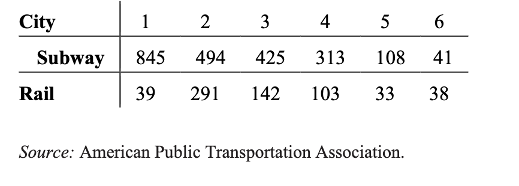

# Solution

## Forming the dataset

```r
subway <- c(845, 494, 425, 313, 108, 41)
rail <- c(39, 291, 142, 103, 33, 38)
```

### Step 1. Find the Spearman rank correlation coefficient

```r
spearman_correlation <- cor(subway, rail, method = "spearman")
spearman_correlation
```

```
## [1] 0.6
```

### Step 2. Stating the hypotheses

The hypothesis for the above will be as follow:

```r
# Print the Null and Alternative Hypothesis
cat("Null Hypothesis (H0): There is no monotonic relationship between subway and rail passengers.\n\n")
```

```
## Null Hypothesis (H0): There is no monotonic relationship between subway and rail passengers.
```

```r
cat("Alternative Hypothesis (H1): There is a monotonic relationship between subway and rail passengers.\n")
```

```
## Alternative Hypothesis (H1): There is a monotonic relationship between subway and rail passengers.
```

### Step 3. Finding the critical value

Finding the critical values at alpha =0.05

```r
# c. Find the critical value
# For a two-tailed test with alpha = 0.05 and df = n - 2 = 4, we use a critical value table or qnorm in R.
n <- length(subway) # Number of observations
critical_value <- qnorm(1 - 0.05/2) / sqrt(n-1)
```

### Step 4. Computing the test results

```r
decision <- abs(spearman_correlation) > critical_value
```

### Step 5. Make the decision

**Rule -**

- Reject the null hypothesis (if the absolute value of the correlation > critical value)
- Fail to reject null hypothesis (if the absolute value of the correlation < critical value).

```r
# e. Summarize the results
summary <- list(
  spearman_correlation = spearman_correlation,
  critical_value = critical_value,
  decision = ifelse(decision, "Reject H0", "Fail to reject H0")
)

# Print the results
print(summary)
```

```
## $spearman_correlation
## [1] 0.6
##
## $critical_value
## [1] 0.8765225
##
## $decision
## [1] "Fail to reject H0"
```

### Step 6. Summary

**We do not reject the null hypothesis.**

Q. Suggest one reason why the transportation authority might use the results of this study.

A. The transportation authority might use the results of a study examining the relationship between subway and commuter rail passengers to optimize transit scheduling and resource allocation. If a positive correlation is found, indicating that high subway usage is associated with high commuter rail usage, the authority could coordinate schedules to ensure that trains are available when and where they are needed most. This could improve the efficiency of the transit system, reduce wait times for passengers, and potentially increase overall user satisfaction. Such data-driven decisions can enhance the operational effectiveness and customer experience of public transportation systems.

# Section 14-3.16 Prizes in Caramel Corn Boxes

A caramel corn company gives four different prizes, one in each box. They are placed in the boxes at

random. Find the average number of boxes a person needs to buy to get all four prizes. (40)

# Solution

```r
set.seed(123) # For reproducibility of results
simulations <- 40

#(OpenAI,2024)
boxes_to_complete_set <- replicate(simulations, {
  prizes <- numeric(4) # To keep track of the number of each prize
  boxes_bought <- 0
  while(min(prizes) == 0) { # Continue buying until we have at least one of each prize
    prize <- sample(1:4, 1) # Randomly select a prize from the 4 types
    prizes[prize] <- prizes[prize] + 1
    boxes_bought <- boxes_bought + 1
  }
  return(boxes_bought)
})
average_boxes <- mean(boxes_to_complete_set)
average_boxes
```

```
## [1] 7.975
```

Interpretation - A person should buy 7.975 boxes to win the prize.

# Section 14-3.18 Lottery Winner

To win a certain lotto, a person must spell the word big. Sixty percent of the tickets contain the letter b,

30% contain the letter i, and 10% contain the letter g. Find the average number of tickets a person must

buy to win the prize. (30)

# Solution

- Code understood by Lab:

```r
set.seed(123) # For reproducibility of results

simulations <- 30

tickets_to_spell_big <- replicate(simulations, {
  word <- c(b = 0, i = 0, g = 0) # To keep track of the letters obtained
  tickets_bought <- 0
  while(min(word) == 0) { # Continue buying until we have all letters
    letter <- sample(c("b", "i", "g"), 1, prob = c(0.6, 0.3, 0.1)) # Choose a letter based on given probabilities
    word[letter] <- word[letter] + 1
    tickets_bought <- tickets_bought + 1
  }
  return(tickets_bought)
})
average_tickets <- mean(tickets_to_spell_big)
average_tickets
```

```
## [1] 11.66667
```

Interpretation - A person should buy 11.66 tickets to win the prize.

# Conclusion

Through the application of nonparametric statistical methods, we have effectively addressed several practical questions. The analyses conducted provided clear outcomes: no significant evidence to challenge the claims regarding game attendance and lottery ticket sales, and no discernible difference in prison sentence lengths or baseball game wins between different groups. Additionally, the simulations yielded average estimates for collecting prizes from caramel corn boxes and winning a lottery game, offering valuable information for strategy and decision-making. These exercises demonstrate the utility and versatility of nonparametric techniques in statistical analysis.

# References

1. OpenAI. (2021). ChatGPT (Version 3.5). OpenAI.https://chat.openai.com/
2. Lab: Nonparametric Statistical Methods and Sampling [Video]. Panopto. Northeastern University
3. Northeastern University. (n.d.). ALY6015 Feature Selection R [PDF file]
4. Northeastern University. (n.d.). ALY6015_Module5_R_Tutorials_WinterA_2024 [.rmd file]